# MidTerm Project CS636

# Preethi Ravulapally (pr454), Sai Lahari Paruchuri (sp2727), Karthik Ganeshula(kg496)

```r
install.packages('fasttime')
```

```r
library(dplyr)
library(lubridate)
```

```r
IBM = read.csv('/Users/karth/Desktop/R/IBM.csv')
MSFT = read.csv('/Users/karth/Desktop/R/MSFT.csv')
GOOG = read.csv('/Users/karth/Desktop/R/GOOG.csv')
AMZN = read.csv('/Users/karth/Desktop/R/AMZN.csv')
AAPL = read.csv('/Users/karth/Desktop/R/AAPL.csv')
FB = read.csv('/Users/karth/Desktop/R/FB.csv')
NFLX = read.csv('/Users/karth/Desktop/R/NFLX.csv')
TSLA = read.csv('/Users/karth/Desktop/R/TSLA.csv')
ORCL = read.csv('/Users/karth/Desktop/R/ORCL.csv')
SAP = read.csv('/Users/karth/Desktop/R/SAP.csv')
JPY = read.csv('/Users/karth/Desktop/R/JPY=X.csv')
'===============IBM==============='
head(IBM)
'===============AAPL=============='
head(MSFT)
'===============AMZN=============='
head(GOOG)
'===============FB================'
head(AMZN)
'===============GOOG=============='
head(AAPL)
'===============MSFT=============='
head(FB)
'===============NFLx=============='
head(NFLX)
'===============ORCL=============='
head(ORCL)
'===============SAP=============='
head(SAP)
'===============TSLA=============='
head(TSLA)
```

'===============IBM==============='

A data.frame: 6 × 7

|  | Date <chr> | Open <dbl> | High <dbl> | Low <dbl> | Close <dbl> | Adj.Close <dbl> | Volume <int> |
| --- | --- | --- | --- | --- | --- | --- | --- |
| 1 | 2018-01-02 | 154.500000 | 154.809998 | 153.539993 | 154.250000 | 132.039154 | 4202500 |
| 2 | 2018-01-03 | 157.339996 | 159.809998 | 156.330002 | 158.490005 | 135.668625 | 9441600 |
| 3 | 2018-01-04 | 159.649994 | 162.320007 | 159.369995 | 161.699997 | 138.416412 | 7556200 |
| 4 | 2018-01-05 | 162.440002 | 162.899994 | 161.100006 | 162.490005 | 139.092651 | 5195800 |
| 5 | 2018-01-08 | 162.660004 | 163.910004 | 161.699997 | 163.470001 | 139.931534 | 5237500 |
| 6 | 2018-01-09 | 163.899994 | 164.529999 | 163.059998 | 163.830002 | 140.239685 | 4341800 |

'===============AAPL=============='

A data.frame: 6 × 7

|  | Date <chr> | Open <dbl> | High <dbl> | Low <dbl> | Close <dbl> | Adj.Close <dbl> | Volume <int> |
| --- | --- | --- | --- | --- | --- | --- | --- |
| 1 | 2018-01-02 | 86.129997 | 86.309998 | 85.500000 | 85.949997 | 82.194328 | 22483800 |
| 2 | 2018-01-03 | 86.059998 | 86.510002 | 85.970001 | 86.349998 | 82.576843 | 26061400 |
| 3 | 2018-01-04 | 86.589996 | 87.660004 | 86.570000 | 87.110001 | 83.303658 | 21912000 |
| 4 | 2018-01-05 | 87.660004 | 88.410004 | 87.430000 | 88.190002 | 84.336464 | 23407100 |
| 5 | 2018-01-08 | 88.199997 | 88.580002 | 87.599998 | 88.279999 | 84.422516 | 22113000 |
| 6 | 2018-01-09 | 88.650002 | 88.730003 | 87.860001 | 88.220001 | 84.365158 | 19484300 |

'===============AMZN=============='

A data.frame: 6 × 7

|  | Date <chr> | Open <dbl> | High <dbl> | Low <dbl> | Close <dbl> | Adj.Close <dbl> | Volume <int> |
| --- | --- | --- | --- | --- | --- | --- | --- |
| 1 | 2018-01-02 | 1048.33997 | 1066.93994 | 1045.22998 | 1065.00000 | 1065.00000 | 1237600 |
| 2 | 2018-01-03 | 1064.31006 | 1086.29004 | 1063.20996 | 1082.47998 | 1082.47998 | 1430200 |
| 3 | 2018-01-04 | 1088.00000 | 1093.56995 | 1084.00195 | 1086.40002 | 1086.40002 | 1004600 |
| 4 | 2018-01-05 | 1094.00000 | 1104.25000 | 1092.00000 | 1102.22998 | 1102.22998 | 1279100 |
| 5 | 2018-01-08 | 1102.22998 | 1111.27002 | 1101.62000 | 1106.93994 | 1106.93994 | 1047600 |
| 6 | 2018-01-09 | 1109.40002 | 1110.56995 | 1101.23096 | 1106.26001 | 1106.26001 | 902500 |

'===============FB================'

A data.frame: 6 × 7

|  | Date <chr> | Open <dbl> | High <dbl> | Low <dbl> | Close <dbl> | Adj.Close <dbl> | Volume <int> |
| --- | --- | --- | --- | --- | --- | --- | --- |
| 1 | 2018-01-02 | 1172.00000 | 1190.00000 | 1170.51001 | 1189.01001 | 1189.01001 | 2694500 |
| 2 | 2018-01-03 | 1188.30005 | 1205.48999 | 1188.30005 | 1204.19995 | 1204.19995 | 3108800 |
| 3 | 2018-01-04 | 1205.00000 | 1215.87000 | 1204.66003 | 1209.58997 | 1209.58997 | 3022100 |
| 4 | 2018-01-05 | 1217.51001 | 1229.14001 | 1210.00000 | 1229.14001 | 1229.14001 | 3544700 |
| 5 | 2018-01-08 | 1236.00000 | 1253.07996 | 1232.03003 | 1246.87000 | 1246.87000 | 4279500 |
| 6 | 2018-01-09 | 1256.90002 | 1259.32996 | 1241.76001 | 1252.69995 | 1252.69995 | 3661300 |

'===============GOOG=============='

A data.frame: 6 × 7

|  | Date <chr> | Open <dbl> | High <dbl> | Low <dbl> | Close <dbl> | Adj.Close <dbl> | Volume <int> |
| --- | --- | --- | --- | --- | --- | --- | --- |
| 1 | 2018-01-02 | 42.540001 | 43.075001 | 42.314999 | 43.064999 | 41.380238 | 102223600 |
| 2 | 2018-01-03 | 43.132500 | 43.637501 | 42.990002 | 43.057499 | 41.373032 | 118071600 |
| 3 | 2018-01-04 | 43.134998 | 43.367500 | 43.020000 | 43.257500 | 41.565216 | 89738400 |
| 4 | 2018-01-05 | 43.360001 | 43.842499 | 43.262501 | 43.750000 | 42.038452 | 94640000 |
| 5 | 2018-01-08 | 43.587502 | 43.902500 | 43.482498 | 43.587502 | 41.882305 | 82271200 |
| 6 | 2018-01-09 | 43.637501 | 43.764999 | 43.352501 | 43.582500 | 41.877506 | 86336000 |

'===============MSFT=============='

A data.frame: 6 × 7

|  | Date <chr> | Open <dbl> | High <dbl> | Low <dbl> | Close <dbl> | Adj.Close <dbl> | Volume <int> |
| --- | --- | --- | --- | --- | --- | --- | --- |
| 1 | 2018-01-02 | 177.679993 | 181.580002 | 177.550003 | 181.419998 | 181.419998 | 18151900 |
| 2 | 2018-01-03 | 181.880005 | 184.779999 | 181.330002 | 184.669998 | 184.669998 | 16886600 |
| 3 | 2018-01-04 | 184.899994 | 186.210007 | 184.100006 | 184.330002 | 184.330002 | 13880900 |
| 4 | 2018-01-05 | 185.589996 | 186.899994 | 184.929993 | 186.850006 | 186.850006 | 13574500 |
| 5 | 2018-01-08 | 187.199997 | 188.899994 | 186.330002 | 188.279999 | 188.279999 | 17994700 |
| 6 | 2018-01-09 | 188.699997 | 188.800003 | 187.100006 | 187.869995 | 187.869995 | 12393100 |

'===============NFLx=============='

A data.frame: 6 × 7

|  | Date <chr> | Open <dbl> | High <dbl> | Low <dbl> | Close <dbl> | Adj.Close <dbl> | Volume <int> |
| --- | --- | --- | --- | --- | --- | --- | --- |
| 1 | 2018-01-02 | 196.100006 | 201.649994 | 195.419998 | 201.070007 | 201.070007 | 10966900 |
| 2 | 2018-01-03 | 202.050003 | 206.210007 | 201.500000 | 205.050003 | 205.050003 | 8591400 |
| 3 | 2018-01-04 | 206.199997 | 207.050003 | 204.000000 | 205.630005 | 205.630005 | 6029600 |
| 4 | 2018-01-05 | 207.250000 | 210.020004 | 205.589996 | 209.990005 | 209.990005 | 7033200 |
| 5 | 2018-01-08 | 210.020004 | 212.500000 | 208.440002 | 212.050003 | 212.050003 | 5580200 |
| 6 | 2018-01-09 | 212.110001 | 212.979996 | 208.589996 | 209.309998 | 209.309998 | 6125900 |

'===============ORCL=============='

A data.frame: 6 × 7

|  | Date <chr> | Open <dbl> | High <dbl> | Low <dbl> | Close <dbl> | Adj.Close <dbl> | Volume <int> |
| --- | --- | --- | --- | --- | --- | --- | --- |
| 1 | 2018-01-02 | 47.570000 | 47.799999 | 46.169998 | 46.630001 | 44.173431 | 25380000 |
| 2 | 2018-01-03 | 47.529999 | 48.070000 | 47.439999 | 47.709999 | 45.196526 | 24165000 |
| 3 | 2018-01-04 | 47.990002 | 48.189999 | 47.720001 | 48.180000 | 45.641769 | 19815100 |
| 4 | 2018-01-05 | 48.419998 | 48.630001 | 48.279999 | 48.470001 | 45.916508 | 14496400 |
| 5 | 2018-01-08 | 48.299999 | 49.070000 | 47.939999 | 48.980000 | 46.399624 | 15075000 |
| 6 | 2018-01-09 | 49.250000 | 49.360001 | 48.919998 | 49.060001 | 46.656403 | 14153700 |

'===============SAP=============='

A data.frame: 6 × 7

|  | Date <chr> | Open <dbl> | High <dbl> | Low <dbl> | Close <dbl> | Adj.Close <dbl> | Volume <int> |
| --- | --- | --- | --- | --- | --- | --- | --- |
| 1 | 2018-01-02 | 111.230003 | 112.419998 | 111.129997 | 112.389999 | 107.653435 | 540600 |
| 2 | 2018-01-03 | 112.629997 | 113.690002 | 112.550003 | 113.309998 | 108.534660 | 506200 |
| 3 | 2018-01-04 | 114.779999 | 115.300003 | 114.699997 | 115.050003 | 110.201332 | 539300 |
| 4 | 2018-01-05 | 115.449997 | 116.500000 | 115.360001 | 116.330002 | 111.427383 | 475300 |
| 5 | 2018-01-08 | 115.089996 | 115.419998 | 114.760002 | 114.800003 | 109.961861 | 515400 |
| 6 | 2018-01-09 | 114.360001 | 114.459999 | 113.449997 | 114.160004 | 109.348839 | 515900 |

'===============TSLA=============='

A data.frame: 6 × 7

|  | Date <chr> | Open <dbl> | High <dbl> | Low <dbl> | Close <dbl> | Adj.Close <dbl> | Volume <int> |
| --- | --- | --- | --- | --- | --- | --- | --- |
| 1 | 2018-01-02 | 62.400002 | 64.421997 | 62.200001 | 64.106003 | 64.106003 | 21761000 |
| 2 | 2018-01-03 | 64.199997 | 65.050003 | 63.110001 | 63.450001 | 63.450001 | 22607500 |
| 3 | 2018-01-04 | 62.574001 | 63.709999 | 61.136002 | 62.924000 | 62.924000 | 49731500 |
| 4 | 2018-01-05 | 63.324001 | 63.448002 | 62.400002 | 63.316002 | 63.316002 | 22956000 |
| 5 | 2018-01-08 | 63.200001 | 67.403999 | 63.099998 | 67.281998 | 67.281998 | 49297000 |
| 6 | 2018-01-09 | 67.031998 | 67.760002 | 65.480003 | 66.737999 | 66.737999 | 35733000 |

```r
universe = data.frame(Date=c(AAPL$Date),"Apple_Close"=c(AAPL$Close),"Apple_AdjClose"=(AAPL$Adj.Close),"Amazon_Close"=c(AMZN$Close),"Amazon_AdjClose"=c(AMZN$Adj.Close),
                      "FB_Close"=c(FB$Close),"FB_AdjClose"=c(FB$Adj.Close),
                      Google_Close=c(GOOG$Close),Google_AdjClose=c(GOOG$Adj.Close),IBM_Close=c(IBM$Close),IBM_AdjClose=c(IBM$Adj.Close),
                      MSFT_Close=c(MSFT$Close),MSFT_AdjClose=c(MSFT$Adj.Close),
                     NFLX_Close=c(NFLX$Close),NFLX_AdjClose=c(NFLX$Adj.Close),ORCL_Close=c(ORCL$Close),ORCL_AdjClose=c(ORCL$Adj.Close),
                      SAP_Close=c(SAP$Close),SAP_AdjClose=c(SAP$Adj.Close),
                     TSLA_Close=c(TSLA$Close),TSLA_AdjClose=c(TSLA$Adj.Close))

Stocks = universe[seq(1,nrow(universe)),]
head(Stocks)
```

A data.frame: 6 × 21

|  | Date <chr> | Apple_Close <dbl> | Apple_AdjClose <dbl> | Amazon_Close <dbl> | Amazon_AdjClose <dbl> | FB_Close <dbl> | FB_AdjClose <dbl> | Google_Close <dbl> | Google_AdjClose <dbl> | IBM_Close <dbl> | ... | MSFT_Close <dbl> | MSFT_AdjClose <dbl> | NFLX_Close <dbl> | NFLX_AdjClose <dbl> | ORCL_Close <dbl> | ORCL_AdjClose <dbl> | SAP_Close <dbl> | SAP_AdjClose <dbl> | TSLA_Close <dbl> | TSLA_AdjClose <dbl> |
| --- | --- | --- | --- | --- | --- | --- | --- | --- | --- | --- | --- | --- | --- | --- | --- | --- | --- | --- | --- | --- | --- |
| 1 | 2018-01-02 | 43.064999 | 41.380238 | 1189.01001 | 1189.01001 | 181.419998 | 181.419998 | 1065.00000 | 1065.00000 | 154.250000 | ... | 85.949997 | 82.194328 | 201.070007 | 201.070007 | 46.630001 | 44.173431 | 112.389999 | 107.653435 | 64.106003 | 64.106003 |
| 2 | 2018-01-03 | 43.057499 | 41.373032 | 1204.19995 | 1204.19995 | 184.669998 | 184.669998 | 1082.47998 | 1082.47998 | 158.490005 | ... | 86.349998 | 82.576843 | 205.050003 | 205.050003 | 47.709999 | 45.196526 | 113.309998 | 108.534660 | 63.450001 | 63.450001 |
| 3 | 2018-01-04 | 43.257500 | 41.565216 | 1209.58997 | 1209.58997 | 184.330002 | 184.330002 | 1086.40002 | 1086.40002 | 161.699997 | ... | 87.110001 | 83.303658 | 205.630005 | 205.630005 | 48.180000 | 45.641769 | 115.050003 | 110.201332 | 62.924000 | 62.924000 |
| 4 | 2018-01-05 | 43.750000 | 42.038452 | 1229.14001 | 1229.14001 | 186.850006 | 186.850006 | 1102.22998 | 1102.22998 | 162.490005 | ... | 88.190002 | 84.336464 | 209.990005 | 209.990005 | 48.470001 | 45.916508 | 116.330002 | 111.427383 | 63.316002 | 63.316002 |
| 5 | 2018-01-08 | 43.587502 | 41.882305 | 1246.87000 | 1246.87000 | 188.279999 | 188.279999 | 1106.93994 | 1106.93994 | 163.470001 | ... | 88.279999 | 84.422516 | 212.050003 | 212.050003 | 48.980000 | 46.399624 | 114.800003 | 109.961861 | 67.281998 | 67.281998 |
| 6 | 2018-01-09 | 43.582500 | 41.877506 | 1252.69995 | 1252.69995 | 187.869995 | 187.869995 | 1106.26001 | 1106.26001 | 163.830002 | ... | 88.220001 | 84.365158 | 209.309998 | 209.309998 | 49.060001 | 46.656403 | 114.160004 | 109.348839 | 66.737999 | 66.737999 |

```r
StockSplit_5 = Stocks[seq(1,nrow(Stocks),5),]
StockSplit_5$Date = as.Date(StockSplit_5$Date)
head(StockSplit_5)
```

A data.frame: 6 × 21

|  | Date <date> | Apple_Close <dbl> | Apple_AdjClose <dbl> | Amazon_Close <dbl> | Amazon_AdjClose <dbl> | FB_Close <dbl> | FB_AdjClose <dbl> | Google_Close <dbl> | Google_AdjClose <dbl> | IBM_Close <dbl> | ... | MSFT_Close <dbl> | MSFT_AdjClose <dbl> | NFLX_Close <dbl> | NFLX_AdjClose <dbl> | ORCL_Close <dbl> | ORCL_AdjClose <dbl> | SAP_Close <dbl> | SAP_AdjClose <dbl> | TSLA_Close <dbl> | TSLA_AdjClose <dbl> |
| --- | --- | --- | --- | --- | --- | --- | --- | --- | --- | --- | --- | --- | --- | --- | --- | --- | --- | --- | --- | --- | --- |
| 1 | 2018-01-02 | 43.064999 | 41.380238 | 1189.01001 | 1189.01001 | 181.419998 | 181.419998 | 1065.00000 | 1065.00000 | 154.250000 | ... | 85.949997 | 82.194328 | 201.070007 | 201.070007 | 46.630001 | 44.173431 | 112.389999 | 107.653435 | 64.106003 | 64.106003 |
| 6 | 2018-01-09 | 43.582500 | 41.877506 | 1252.69995 | 1252.69995 | 187.869995 | 187.869995 | 1106.26001 | 1106.26001 | 163.830002 | ... | 88.220001 | 84.365158 | 209.309998 | 209.309998 | 49.060001 | 46.656403 | 114.160004 | 109.348839 | 66.737999 | 66.737999 |
| 11 | 2018-01-17 | 44.775002 | 43.023350 | 1295.00000 | 1295.00000 | 177.600006 | 177.600006 | 1131.97998 | 1131.97998 | 168.649994 | ... | 90.139999 | 86.201241 | 217.500000 | 217.500000 | 50.270000 | 47.807117 | 111.190002 | 106.504013 | 69.431999 | 69.431999 |
| 16 | 2018-01-24 | 43.555000 | 41.851074 | 1357.51001 | 1357.51001 | 186.550003 | 186.550003 | 1164.23999 | 1164.23999 | 165.369995 | ... | 91.820000 | 87.807838 | 261.299988 | 261.299988 | 51.450001 | 48.929306 | 114.370003 | 109.549988 | 69.178001 | 69.178001 |
| 21 | 2018-01-31 | 41.857498 | 40.219990 | 1450.89001 | 1450.89001 | 186.889999 | 186.889999 | 1169.93994 | 1169.93994 | 163.699997 | ... | 95.010002 | 90.858444 | 270.299988 | 270.299988 | 51.590000 | 49.062439 | 113.250000 | 108.477188 | 70.862000 | 70.862000 |
| 26 | 2018-02-07 | 39.884998 | 38.324650 | 1416.78003 | 1416.78003 | 180.179993 | 180.179993 | 1048.57996 | 1048.57996 | 153.850006 | ... | 89.610001 | 85.694405 | 264.559998 | 264.559998 | 48.869999 | 46.475712 | 105.089996 | 100.661079 | 69.000000 | 69.000000 |

```r
StockSplit_5[StockSplit_5$Date=='2018-01-02',]
```

A data.frame: 1 × 21

|  | Date <date> | Apple_Close <dbl> | Apple_AdjClose <dbl> | Amazon_Close <dbl> | Amazon_AdjClose <dbl> | FB_Close <dbl> | FB_AdjClose <dbl> | Google_Close <dbl> | Google_AdjClose <dbl> | IBM_Close <dbl> | ... | MSFT_Close <dbl> | MSFT_AdjClose <dbl> | NFLX_Close <dbl> | NFLX_AdjClose <dbl> | ORCL_Close <dbl> | ORCL_AdjClose <dbl> | SAP_Close <dbl> | SAP_AdjClose <dbl> | TSLA_Close <dbl> | TSLA_AdjClose <dbl> |
| --- | --- | --- | --- | --- | --- | --- | --- | --- | --- | --- | --- | --- | --- | --- | --- | --- | --- | --- | --- | --- | --- |
| 1 | 2018-01-02 | 43.064999 | 41.380238 | 1189.01001 | 1189.01001 | 181.419998 | 181.419998 | 1065 | 1065 | 154.25 | ... | 85.949997 | 82.194328 | 201.070007 | 201.070007 | 46.630001 | 44.173431 | 112.389999 | 107.653435 | 64.106003 | 64.106003 |

```r
a = StockSplit_5[StockSplit_5$Date=='2018-01-02',
                  c('IBM_Close','MSFT_Close','Google_Close','Amazon_Close','FB_Close')]
a
```

A data.frame: 1 × 5

|  | IBM_Close <dbl> | MSFT_Close <dbl> | Google_Close <dbl> | Amazon_Close <dbl> | FB_Close <dbl> |
| --- | --- | --- | --- | --- | --- |
| 1 | 154.25 | 85.949997 | 1065 | 1189.01001 | 181.419998 |

# Strategy 1 without Dividends

The following is the code for the first strategy by which we should end up with a profit by the end of the year because we are buying low stocks.

```r
Total = 5000000
options(digits=9)
Remaining = Total
split = Total/5
MTM = 0
start_date = mdy('01/02/2018')
begin_date <- mdy('01/02/2018')
end_date =  mdy('12/28/2018')
AllStocks = c('IBM_AdjClose','MSFT_AdjClose','Google_AdjClose','Apple_AdjClose','Amazon_AdjClose','FB_AdjClose','NFLX_AdjClose','TSLA_AdjClose','ORCL_AdjClose','SAP_AdjClose')
IntialStocks = c('IBM_Close','MSFT_Close','Google_Close','Amazon_Close','FB_Close')
SharesCount = list()


while(start_date <= end_date){
    # executes the first day
    if(start_date == '2018-01-02'){
          for(i in IntialStocks) {
        a = Stocks[Stocks$Date== start_date, IntialStocks]
        b= floor(split/a[i])
        SharesCount[i] =  b[[i]]
        Remaining = Remaining - b*a[i]
        MTM = MTM + b*a[i]
        }
        colnames(Remaining) = 'Remaining'
        Stocks[Stocks$Date == start_date,'Remaining'] = Remaining
        colnames(MTM) = 'MTM'
        MTM = MTM + Remaining
        Stocks[Stocks$Date == start_date,'MTM'] = MTM

    }



    else if(start_date %in% StockSplit_5$Date) {

        MTM = 0
        for(i in IntialStocks) {
        a = Stocks[Stocks$Date== start_date, IntialStocks]
        MTM = MTM + SharesCount[[i]]*a[i]
        }
        Total = MTM + Remaining
        Remaining = Total
        split = Total / 5
        colnames(Total) = 'Total'
        colnames(MTM) = 'MTM'
        calculated_stocks = list()
        for(i in AllStocks){

            x = Stocks[Stocks$Date== start_date, AllStocks]
            y = Stocks[Stocks$Date== begin_date, AllStocks]
            percent_change = 100 * ((x[i] - y[i])/ y[i])
            col = paste0(i, "_PC")
            calculated_stocks[col] = percent_change

        }
        calculated_stocks = calculated_stocks[order(unlist(calculated_stocks))]
        calculated_stocks = head(calculated_stocks,5)


        initial_col_list = names(calculated_stocks)
        print(initial_col_list)
        initial_col_list = sub('_.*','',initial_col_list)
        initial_col_list = paste0(initial_col_list,'_Close')
        IntialStocks = initial_col_list
        SharesCount = list()
        b = list()
        MTM = 0
        for(i in IntialStocks) {
        a = Stocks[Stocks$Date== start_date, IntialStocks]
        b= floor(split[,1]/a[i])
        SharesCount[i] =  b[[i]]
        Remaining = Remaining - b*a[i]
        MTM = MTM + b*a[i]
        }
        MTM = MTM + Remaining
        Stocks[Stocks$Date == start_date,'MTM'] = MTM
        Stocks[Stocks$Date == start_date,'Remaining'] = Remaining


    }


    else {
        MTM = 0
        for(i in IntialStocks) {
        a = Stocks[Stocks$Date== start_date, IntialStocks]
        MTM = MTM + SharesCount[[i]]*a[i]
        }
        colnames(MTM) = 'MTM'
        Stocks[Stocks$Date == start_date,'Remaining'] = Remaining
        Stocks[Stocks$Date == start_date,'MTM'] = MTM

    }
start_date = start_date+1

}
sr1_5 = c('StockSplit_5',MTM = tail(Stocks$MTM,1))
output_1 = c('Profit:', MTM-5000000)
sr1_5
output_1
tail(Stocks)
```

```
[1] "Apple_AdjClose_PC"  "SAP_AdjClose_PC"    "MSFT_AdjClose_PC"
[4] "FB_AdjClose_PC"     "Google_AdjClose_PC"
[1] "FB_AdjClose_PC"     "SAP_AdjClose_PC"    "Apple_AdjClose_PC"
[4] "MSFT_AdjClose_PC"   "Google_AdjClose_PC"
[1] "Apple_AdjClose_PC" "SAP_AdjClose_PC"   "FB_AdjClose_PC"
[4] "MSFT_AdjClose_PC"  "IBM_AdjClose_PC"
[1] "Apple_AdjClose_PC"  "SAP_AdjClose_PC"    "FB_AdjClose_PC"
[4] "IBM_AdjClose_PC"    "Google_AdjClose_PC"
[1] "Apple_AdjClose_PC"  "SAP_AdjClose_PC"    "Google_AdjClose_PC"
[4] "FB_AdjClose_PC"     "IBM_AdjClose_PC"
[1] "SAP_AdjClose_PC"    "Apple_AdjClose_PC"  "FB_AdjClose_PC"
[4] "Google_AdjClose_PC" "TSLA_AdjClose_PC"
[1] "SAP_AdjClose_PC"    "FB_AdjClose_PC"     "IBM_AdjClose_PC"
[4] "Apple_AdjClose_PC"  "Google_AdjClose_PC"
[1] "SAP_AdjClose_PC"    "FB_AdjClose_PC"     "Google_AdjClose_PC"
```

[output cut: 83 more lines]

**1**

'StockSplit_5'

**MTM**

'5323137.228935'

**[[1]]**

'Profit:'

**$MTM**

323137.228935

A data.frame: 6 × 24

|  | Date <chr> | Apple_Close <dbl> | Apple_AdjClose <dbl> | Amazon_Close <dbl> | Amazon_AdjClose <dbl> | FB_Close <dbl> | FB_AdjClose <dbl> | Google_Close <dbl> | Google_AdjClose <dbl> | IBM_Close <dbl> | ... | NFLX_AdjClose <dbl> | ORCL_Close <dbl> | ORCL_AdjClose <dbl> | SAP_Close <dbl> | SAP_AdjClose <dbl> | TSLA_Close <dbl> | TSLA_AdjClose <dbl> | Remaining <dbl> | MTM <dbl> | HTI <dbl> |
| --- | --- | --- | --- | --- | --- | --- | --- | --- | --- | --- | --- | --- | --- | --- | --- | --- | --- | --- | --- | --- | --- |
| 245 | 2018-12-20 | 39.207500 | 38.239254 | 1460.82996 | 1460.82996 | 133.399994 | 133.399994 | 1009.409973 | 1009.409973 | 113.019997 | ... | 260.579987 | 46.240002 | 44.508316 | 100.099998 | 97.349060 | 63.076000 | 63.076000 | 787.994654 | 5307895.74 | 332.737341 |
| 246 | 2018-12-21 | 37.682499 | 36.751911 | 1377.44995 | 1377.44995 | 124.949997 | 124.949997 | 979.539978 | 979.539978 | 110.940002 | ... | 246.389999 | 44.000000 | 42.352196 | 96.139999 | 93.497879 | 63.953999 | 63.953999 | 1112.270492 | 5107817.05 | 317.927643 |
| 247 | 2018-12-24 | 36.707500 | 35.800995 | 1343.95996 | 1343.95996 | 124.059998 | 124.059998 | 976.219971 | 976.219971 | 107.570000 | ... | 233.880005 | 42.689999 | 41.091255 | 95.000000 | 92.389214 | 59.077999 | 59.077999 | 1112.270492 | 5026394.87 | 311.329543 |
| 248 | 2018-12-26 | 39.292500 | 38.322155 | 1470.90002 | 1470.90002 | 134.179993 | 134.179993 | 1039.459961 | 1039.459961 | 111.389999 | ... | 253.669998 | 44.590000 | 42.920109 | 98.379997 | 95.676323 | 65.218002 | 65.218002 | 1112.270492 | 5316185.68 | 335.764047 |
| 249 | 2018-12-27 | 39.037498 | 38.073456 | 1461.64001 | 1461.64001 | 134.520004 | 134.520004 | 1043.880005 | 1043.880005 | 113.779999 | ... | 255.570007 | 44.970001 | 43.285877 | 98.989998 | 96.269554 | 63.226002 | 63.226002 | 1112.270492 | 5345146.49 | 335.679353 |
| 250 | 2018-12-28 | 39.057499 | 38.092960 | 1478.02002 | 1478.02002 | 133.199997 | 133.199997 | 1037.079956 | 1037.079956 | 113.029999 | ... | 256.079987 | 44.820000 | 43.141491 | 99.199997 | 96.473793 | 66.774002 | 66.774002 | 1112.270492 | 5323137.23 | 336.765146 |

From the above output, we can say that we ended up with a profit of 323137.228935.

The following code shows the execution of the second strategy, by buying high stocks and ending uo with a loss.

# Strategy 2 without Dividends

```r
options(digits=9)
Total = 5000000
Remaining = Total
split = Total/5
MTM = 0
begin_date = mdy('01/02/2018')
start_date = begin_date
end_date =  mdy('12/28/2018')
AllStocks = c('IBM_AdjClose','MSFT_AdjClose','Google_AdjClose','Apple_AdjClose','Amazon_AdjClose','FB_AdjClose','NFLX_AdjClose','TSLA_AdjClose','ORCL_AdjClose','SAP_AdjClose')
IntialStocks = c('IBM_Close','MSFT_Close','Google_Close','Amazon_Close','FB_Close')
SharesCount = list()


while(start_date <= end_date){

    if(start_date == '2018-01-02'){
          for(i in IntialStocks) {
        a = Stocks[Stocks$Date== start_date, IntialStocks]
        b= floor(split/a[i])
        SharesCount[i] =  b[[i]]
        Remaining = Remaining - b*a[i]
        MTM = MTM + b*a[i]
        }
        colnames(Remaining) = 'Remaining'
        Stocks[Stocks$Date == start_date,'Remaining'] = Remaining
        colnames(MTM) = 'MTM'
        MTM = MTM + Remaining
        Stocks[Stocks$Date == start_date,'MTM'] = MTM

}

        else if(start_date %in% StockSplit_5$Date) {
        MTM = 0
        for(i in IntialStocks) {
        a = Stocks[Stocks$Date== start_date, IntialStocks]
        MTM = MTM + SharesCount[[i]]*a[i]
        }
        Total = MTM + Remaining
        Remaining = Total
        split = Total / 5
        colnames(Total) = 'Total'
        colnames(MTM) = 'MTM'
        calculated_stocks = list()
        for(i in AllStocks){

            x = Stocks[Stocks$Date== start_date, AllStocks]
            y = Stocks[Stocks$Date== begin_date, AllStocks]
            percent_change = 100 * ((x[i] - y[i])/ y[i])
            col = paste0(i, "_PC")
            calculated_stocks[col] = percent_change

        }
        calculated_stocks = calculated_stocks[order(unlist(calculated_stocks))]
        calculated_stocks = tail(calculated_stocks,5)


        initial_col_list = names(calculated_stocks)
        initial_col_list = sub('_.*','',initial_col_list)
        initial_col_list = paste0(initial_col_list,'_Close')
        IntialStocks = initial_col_list
        SharesCount = list()
        b = list()
        MTM = 0
        for(i in IntialStocks) {
        a = Stocks[Stocks$Date== start_date, IntialStocks]
        b= floor(split[,1]/a[i])
        SharesCount[i] =  b[[i]]
        Remaining = Remaining - b*a[i]
        MTM = MTM + b*a[i]
        }
        MTM = MTM + Remaining
        Stocks[Stocks$Date == start_date,'MTM'] = MTM
        Stocks[Stocks$Date == start_date,'Remaining'] = Remaining


    }

    else {
        MTM = 0
        for(i in IntialStocks) {
        a = Stocks[Stocks$Date== start_date, IntialStocks]
        MTM = MTM + SharesCount[[i]]*a[i]
        }
        colnames(MTM) = 'MTM'
        Stocks[Stocks$Date == start_date,'Remaining'] = Remaining
        Stocks[Stocks$Date == start_date,'MTM'] = MTM

    }
start_date = start_date+1
}
sr2_5 = c('StockSplit_5',MTM = tail(Stocks$MTM,1))
output_2 = c('Loss:', 5000000 - MTM)
sr2_5
output_2
tail(Stocks)
```

**1**

'StockSplit_5'

**MTM**

'4761841.916281'

**[[1]]**

'Loss:'

**$MTM**

238158.083719

A data.frame: 6 × 24

|  | Date <chr> | Apple_Close <dbl> | Apple_AdjClose <dbl> | Amazon_Close <dbl> | Amazon_AdjClose <dbl> | FB_Close <dbl> | FB_AdjClose <dbl> | Google_Close <dbl> | Google_AdjClose <dbl> | IBM_Close <dbl> | ... | NFLX_AdjClose <dbl> | ORCL_Close <dbl> | ORCL_AdjClose <dbl> | SAP_Close <dbl> | SAP_AdjClose <dbl> | TSLA_Close <dbl> | TSLA_AdjClose <dbl> | Remaining <dbl> | MTM <dbl> | HTI <dbl> |
| --- | --- | --- | --- | --- | --- | --- | --- | --- | --- | --- | --- | --- | --- | --- | --- | --- | --- | --- | --- | --- | --- |
| 245 | 2018-12-20 | 39.207500 | 38.239254 | 1460.82996 | 1460.82996 | 133.399994 | 133.399994 | 1009.409973 | 1009.409973 | 113.019997 | ... | 260.579987 | 46.240002 | 44.508316 | 100.099998 | 97.349060 | 63.076000 | 63.076000 | 1507.778059 | 4754545.38 | 332.737341 |
| 246 | 2018-12-21 | 37.682499 | 36.751911 | 1377.44995 | 1377.44995 | 124.949997 | 124.949997 | 979.539978 | 979.539978 | 110.940002 | ... | 246.389999 | 44.000000 | 42.352196 | 96.139999 | 93.497879 | 63.953999 | 63.953999 | 455.362628 | 4581750.35 | 317.927643 |
| 247 | 2018-12-24 | 36.707500 | 35.800995 | 1343.95996 | 1343.95996 | 124.059998 | 124.059998 | 976.219971 | 976.219971 | 107.570000 | ... | 233.880005 | 42.689999 | 41.091255 | 95.000000 | 92.389214 | 59.077999 | 59.077999 | 455.362628 | 4377109.21 | 311.329543 |
| 248 | 2018-12-26 | 39.292500 | 38.322155 | 1470.90002 | 1470.90002 | 134.179993 | 134.179993 | 1039.459961 | 1039.459961 | 111.389999 | ... | 253.669998 | 44.590000 | 42.920109 | 98.379997 | 95.676323 | 65.218002 | 65.218002 | 455.362628 | 4722645.77 | 335.764047 |
| 249 | 2018-12-27 | 39.037498 | 38.073456 | 1461.64001 | 1461.64001 | 134.520004 | 134.520004 | 1043.880005 | 1043.880005 | 113.779999 | ... | 255.570007 | 44.970001 | 43.285877 | 98.989998 | 96.269554 | 63.226002 | 63.226002 | 455.362628 | 4708709.90 | 335.679353 |
| 250 | 2018-12-28 | 39.057499 | 38.092960 | 1478.02002 | 1478.02002 | 133.199997 | 133.199997 | 1037.079956 | 1037.079956 | 113.029999 | ... | 256.079987 | 44.820000 | 43.141491 | 99.199997 | 96.473793 | 66.774002 | 66.774002 | 455.362628 | 4761841.92 | 336.765146 |

# Calculating Dividends

```r
IBM1 =IBM %>%
  mutate(Ratio.AdjClose = lag(Adj.Close, default = 0) / Adj.Close,
        Ratio.Close = lag(Close, default = 0) / Close) %>%
  mutate(IBM,Difference = Ratio.AdjClose-Ratio.Close) %>%
  mutate(IBM, Dividend = Difference*Close)
 IBM1$IBM_Absolute_Dividend = abs(IBM1$Dividend)
IBM1 =  rename(IBM1, 'IBM_Date' = 'Date')
IBM1 = select (IBM1, IBM_Date, IBM_Absolute_Dividend) %>%
filter (IBM_Absolute_Dividend > 0.01)

IBM1
```

A data.frame: 4 × 2

| IBM_Date <chr> | IBM_Absolute_Dividend <dbl> |
| --- | --- |
| 2018-02-08 | 1.50001602 |
| 2018-05-09 | 1.56998990 |
| 2018-08-09 | 1.57001517 |
| 2018-11-08 | 1.57000693 |

```r
amzn1 =AMZN %>%
  mutate(Ratio.AdjClose = lag(Adj.Close, default = 0) / Adj.Close,
        Ratio.Close = lag(Close, default = 0) / Close) %>%
  mutate(AMZN,Difference = Ratio.AdjClose-Ratio.Close) %>%
  mutate(AMZN, Dividend = Difference*Close)
 amzn1$Absolute_Dividend = abs(amzn1$Dividend)
select (amzn1, Date, Absolute_Dividend) %>%
filter (Absolute_Dividend > 0.01)
```

A data.frame: 0 × 2

| Date | Absolute_Dividend |
| --- | --- |
| <chr> | <dbl> |

```r
msft1 =MSFT %>%
  mutate(Ratio.AdjClose = lag(Adj.Close, default = 0) / Adj.Close,
        Ratio.Close = lag(Close, default = 0) / Close) %>%
  mutate(MSFT,Difference = Ratio.AdjClose-Ratio.Close) %>%
  mutate(MSFT, Dividend = Difference*Close)
 msft1$MSFT_Absolute_Dividend = abs(msft1$Dividend)
msft1 =  rename(msft1, 'MSFT_Date' = 'Date')
msft1 = select (msft1, MSFT_Date, MSFT_Absolute_Dividend) %>%
filter (MSFT_Absolute_Dividend > 0.01)
msft1
```

A data.frame: 4 × 2

| MSFT_Date <chr> | MSFT_Absolute_Dividend <dbl> |
| --- | --- |
| 2018-02-14 | 0.419996807 |
| 2018-05-16 | 0.419999912 |
| 2018-08-15 | 0.419991628 |
| 2018-11-14 | 0.460009091 |

```r
goog1 =GOOG %>%
  mutate(Ratio.AdjClose = lag(Adj.Close, default = 0) / Adj.Close,
        Ratio.Close = lag(Close, default = 0) / Close) %>%
  mutate(GOOG,Difference = Ratio.AdjClose-Ratio.Close) %>%
  mutate(GOOG, Dividend = Difference*Close)
 goog1$Absolute_Dividend = abs(goog1$Dividend)
select (goog1, Date, Absolute_Dividend) %>%
filter (Absolute_Dividend > 0.01)
```

A data.frame: 0 × 2

| Date | Absolute_Dividend |
| --- | --- |
| <chr> | <dbl> |

```r
aapl1 =AAPL %>%
  mutate(Ratio.AdjClose = lag(Adj.Close, default = 0) / Adj.Close,
        Ratio.Close = lag(Close, default = 0) / Close) %>%
  mutate(AAPL,Difference = Ratio.AdjClose-Ratio.Close) %>%
  mutate(AAPL, Dividend = Difference*Close)
 aapl1$AAPL_Absolute_Dividend = abs(aapl1$Dividend)

aapl1 =  rename(aapl1, 'AAPL_Date' = 'Date')
aapl1 = select (aapl1, AAPL_Date, AAPL_Absolute_Dividend) %>%
filter (AAPL_Absolute_Dividend > 0.01)
aapl1
```

A data.frame: 4 × 2

| AAPL_Date <chr> | AAPL_Absolute_Dividend <dbl> |
| --- | --- |
| 2018-02-09 | 0.157498766 |
| 2018-05-11 | 0.182500050 |
| 2018-08-10 | 0.182501594 |
| 2018-11-08 | 0.182502211 |

```r
fb1 =FB %>%
  mutate(Ratio.AdjClose = lag(Adj.Close, default = 0) / Adj.Close,
        Ratio.Close = lag(Close, default = 0) / Close) %>%
  mutate(FB,Difference = Ratio.AdjClose-Ratio.Close) %>%
  mutate(FB, Dividend = Difference*Close)
 fb1$Absolute_Dividend = abs(fb1$Dividend)
select (fb1, Date, Absolute_Dividend) %>%
filter (Absolute_Dividend > 0.01)
```

A data.frame: 0 × 2

| Date | Absolute_Dividend |
| --- | --- |
| <chr> | <dbl> |

```r
nflx1 =NFLX %>%
  mutate(Ratio.AdjClose = lag(Adj.Close, default = 0) / Adj.Close,
        Ratio.Close = lag(Close, default = 0) / Close) %>%
  mutate(NFLX,Difference = Ratio.AdjClose-Ratio.Close) %>%
  mutate(NFLX, Dividend = Difference*Close)
 nflx1$Absolute_Dividend = abs(nflx1$Dividend)
select (nflx1, Date, Absolute_Dividend) %>%
filter (Absolute_Dividend > 0.01)
```

A data.frame: 0 × 2

| Date | Absolute_Dividend |
| --- | --- |
| <chr> | <dbl> |

```r
tsla1 =TSLA %>%
  mutate(Ratio.AdjClose = lag(Adj.Close, default = 0) / Adj.Close,
        Ratio.Close = lag(Close, default = 0) / Close) %>%
  mutate(TSLA,Difference = Ratio.AdjClose-Ratio.Close) %>%
  mutate(TSLA, Dividend = Difference*Close)
 tsla1$Absolute_Dividend = abs(tsla1$Dividend)
select (tsla1, Date, Absolute_Dividend) %>%
filter (Absolute_Dividend > 0.01)
```

A data.frame: 0 × 2

| Date | Absolute_Dividend |
| --- | --- |
| <chr> | <dbl> |

```r
orcl1 =ORCL %>%
  mutate(Ratio.AdjClose = lag(Adj.Close, default = 0) / Adj.Close,
        Ratio.Close = lag(Close, default = 0) / Close) %>%
  mutate(ORCL,Difference = Ratio.AdjClose-Ratio.Close) %>%
  mutate(ORCL, Dividend = Difference*Close)
 orcl1$ORCL_Absolute_Dividend = abs(orcl1$Dividend)

orcl1 =  rename(orcl1, 'ORCL_Date' = 'Date')
orcl1 = select (orcl1, ORCL_Date, ORCL_Absolute_Dividend) %>%
filter (ORCL_Absolute_Dividend > 0.01)
orcl1
```

A data.frame: 4 × 2

| ORCL_Date <chr> | ORCL_Absolute_Dividend <dbl> |
| --- | --- |
| 2018-01-09 | 0.190006484 |
| 2018-04-16 | 0.189997654 |
| 2018-07-16 | 0.190000122 |
| 2018-10-15 | 0.189993168 |

```r
sap1 =SAP %>%
  mutate(Ratio.AdjClose = lag(Adj.Close, default = 0) / Adj.Close,
        Ratio.Close = lag(Close, default = 0) / Close) %>%
  mutate(SAP,Difference = Ratio.AdjClose-Ratio.Close) %>%
  mutate(SAP, Dividend = Difference*Close)
 sap1$SAP_Absolute_Dividend = abs(sap1$Dividend)

sap1 =  rename(sap1, 'SAP_Date' = 'Date')
sap1 =  select (sap1, SAP_Date, SAP_Absolute_Dividend)%>%
filter (SAP_Absolute_Dividend > 0.01)
sap1
```

A data.frame: 1 × 2

| SAP_Date <chr> | SAP_Absolute_Dividend <dbl> |
| --- | --- |
| 2018-05-18 | 1.72700599 |

```r
dividend_stocks = cbind(IBM1,msft1,aapl1,orcl1,sap1)
dividend_stocks
```

A data.frame: 4 × 10

| IBM_Date <chr> | IBM_Absolute_Dividend <dbl> | MSFT_Date <chr> | MSFT_Absolute_Dividend <dbl> | AAPL_Date <chr> | AAPL_Absolute_Dividend <dbl> | ORCL_Date <chr> | ORCL_Absolute_Dividend <dbl> | SAP_Date <chr> | SAP_Absolute_Dividend <dbl> |
| --- | --- | --- | --- | --- | --- | --- | --- | --- | --- |
| 2018-02-08 | 1.50001602 | 2018-02-14 | 0.419996807 | 2018-02-09 | 0.157498766 | 2018-01-09 | 0.190006484 | 2018-05-18 | 1.72700599 |
| 2018-05-09 | 1.56998990 | 2018-05-16 | 0.419999912 | 2018-05-11 | 0.182500050 | 2018-04-16 | 0.189997654 | 2018-05-18 | 1.72700599 |
| 2018-08-09 | 1.57001517 | 2018-08-15 | 0.419991628 | 2018-08-10 | 0.182501594 | 2018-07-16 | 0.190000122 | 2018-05-18 | 1.72700599 |
| 2018-11-08 | 1.57000693 | 2018-11-14 | 0.460009091 | 2018-11-08 | 0.182502211 | 2018-10-15 | 0.189993168 | 2018-05-18 | 1.72700599 |

# Strategy 1 with Dividends

```r
options(digits=9)
Total = 5000000
Remaining = Total
split = Total/5
MTM = 0
begin_date = mdy('01/02/2018')
start_date = begin_date
end_date =  mdy('12/28/2018')
AllStocks = c('IBM_AdjClose','MSFT_AdjClose','Google_AdjClose','Apple_AdjClose','Amazon_AdjClose','FB_AdjClose','NFLX_AdjClose','TSLA_AdjClose','ORCL_AdjClose','SAP_AdjClose')
IntialStocks = c('IBM_Close','MSFT_Close','Google_Close','Amazon_Close','FB_Close')
SharesCount = list()


while(start_date <= end_date){


    if(start_date == '2018-01-02'){
          for(i in IntialStocks) {
        a = Stocks[Stocks$Date== start_date, IntialStocks]
        b= floor(split/a[i])
        SharesCount[i] =  b[[i]]
        Remaining = Remaining - b*a[i]
        st_name= sub('_.*','',i)
        name = paste0(st_name,'_','Date')
        name = as.name(name)

        value = paste0(st_name,'_Absolute_Dividend')
        value = as.name(value)


        print(dividend_stocks$IBM_Date)

        if(start_date %in% dividend_stocks$name){

            print('Hello')

        }

        MTM = MTM + b*a[i]
        }



}



    else if(start_date %in% StockSplit_5$Date) {
        MTM = 0
        for(i in IntialStocks) {
        a = Stocks[Stocks$Date== start_date, IntialStocks]
        MTM = MTM + SharesCount[[i]]*a[i]
        }
        Total = MTM + Remaining
        Remaining = Total
        split = Total / 5
        colnames(Total) = 'Total'
        colnames(MTM) = 'MTM'
        calculated_stocks = list()
        for(i in AllStocks){

            x = Stocks[Stocks$Date== start_date, AllStocks]
            y = Stocks[Stocks$Date== begin_date, AllStocks]
            percent_change = 100 * ((x[i] - y[i])/ y[i])
            col = paste0(i, "_PC")
            calculated_stocks[col] = percent_change

        }
        calculated_stocks = calculated_stocks[order(unlist(calculated_stocks))]
        calculated_stocks = head(calculated_stocks,5)

        # update initial stocks
        initial_col_list = names(calculated_stocks)
        initial_col_list = sub('_.*','',initial_col_list)
        initial_col_list = paste0(initial_col_list,'_Close')
        IntialStocks = initial_col_list
        SharesCount = list()
        b = list()
        MTM = 0
        for(i in IntialStocks) {
        a = Stocks[Stocks$Date== start_date, IntialStocks]
        b= floor(split[,1]/a[i])
        SharesCount[i] =  b[[i]]
        Remaining = Remaining - b*a[i]
        MTM = MTM + b*a[i]
        }
        MTM = MTM + Remaining
        Stocks[Stocks$Date == start_date,'MTM'] = MTM
        Stocks[Stocks$Date == start_date,'Remaining'] = Remaining


    }

    # This logic executes every day except the 5th day and returns MTM
    else {
        MTM = 0
        for(i in IntialStocks) {
        a = Stocks[Stocks$Date== start_date, IntialStocks]
        MTM = MTM + SharesCount[[i]]*a[i]
        }
        colnames(MTM) = 'MTM'
        Stocks[Stocks$Date == start_date,'Remaining'] = Remaining
        Stocks[Stocks$Date == start_date,'MTM'] = MTM

    }

start_date = start_date+1

}
sr1_5 = c('StockSplit_5',MTM = tail(Stocks$MTM,1))
output_3 = c('Profit:', MTM-5000000)
sr1_5
output_3
tail(Stocks)
```

```
[1] "2018-02-08" "2018-05-09" "2018-08-09" "2018-11-08"
[1] "2018-02-08" "2018-05-09" "2018-08-09" "2018-11-08"
[1] "2018-02-08" "2018-05-09" "2018-08-09" "2018-11-08"
[1] "2018-02-08" "2018-05-09" "2018-08-09" "2018-11-08"
[1] "2018-02-08" "2018-05-09" "2018-08-09" "2018-11-08"
```

**1**

'StockSplit_5'

**MTM**

'5323137.228935'

**[[1]]**

'Profit:'

**$MTM**

323137.228935

A data.frame: 6 × 24

|  | Date <chr> | Apple_Close <dbl> | Apple_AdjClose <dbl> | Amazon_Close <dbl> | Amazon_AdjClose <dbl> | FB_Close <dbl> | FB_AdjClose <dbl> | Google_Close <dbl> | Google_AdjClose <dbl> | IBM_Close <dbl> | ... | NFLX_AdjClose <dbl> | ORCL_Close <dbl> | ORCL_AdjClose <dbl> | SAP_Close <dbl> | SAP_AdjClose <dbl> | TSLA_Close <dbl> | TSLA_AdjClose <dbl> | Remaining <dbl> | MTM <dbl> | HTI <dbl> |
| --- | --- | --- | --- | --- | --- | --- | --- | --- | --- | --- | --- | --- | --- | --- | --- | --- | --- | --- | --- | --- | --- |
| 245 | 2018-12-20 | 39.207500 | 38.239254 | 1460.82996 | 1460.82996 | 133.399994 | 133.399994 | 1009.409973 | 1009.409973 | 113.019997 | ... | 260.579987 | 46.240002 | 44.508316 | 100.099998 | 97.349060 | 63.076000 | 63.076000 | 787.994654 | 5307895.74 | 332.737341 |
| 246 | 2018-12-21 | 37.682499 | 36.751911 | 1377.44995 | 1377.44995 | 124.949997 | 124.949997 | 979.539978 | 979.539978 | 110.940002 | ... | 246.389999 | 44.000000 | 42.352196 | 96.139999 | 93.497879 | 63.953999 | 63.953999 | 1112.270492 | 5107817.05 | 317.927643 |
| 247 | 2018-12-24 | 36.707500 | 35.800995 | 1343.95996 | 1343.95996 | 124.059998 | 124.059998 | 976.219971 | 976.219971 | 107.570000 | ... | 233.880005 | 42.689999 | 41.091255 | 95.000000 | 92.389214 | 59.077999 | 59.077999 | 1112.270492 | 5026394.87 | 311.329543 |
| 248 | 2018-12-26 | 39.292500 | 38.322155 | 1470.90002 | 1470.90002 | 134.179993 | 134.179993 | 1039.459961 | 1039.459961 | 111.389999 | ... | 253.669998 | 44.590000 | 42.920109 | 98.379997 | 95.676323 | 65.218002 | 65.218002 | 1112.270492 | 5316185.68 | 335.764047 |
| 249 | 2018-12-27 | 39.037498 | 38.073456 | 1461.64001 | 1461.64001 | 134.520004 | 134.520004 | 1043.880005 | 1043.880005 | 113.779999 | ... | 255.570007 | 44.970001 | 43.285877 | 98.989998 | 96.269554 | 63.226002 | 63.226002 | 1112.270492 | 5345146.49 | 335.679353 |
| 250 | 2018-12-28 | 39.057499 | 38.092960 | 1478.02002 | 1478.02002 | 133.199997 | 133.199997 | 1037.079956 | 1037.079956 | 113.029999 | ... | 256.079987 | 44.820000 | 43.141491 | 99.199997 | 96.473793 | 66.774002 | 66.774002 | 1112.270492 | 5323137.23 | 336.765146 |

# Strategy 2 with Dividends

```r
#Strategy 2 with dividends

options(digits=9)
Total = 5000000
Remaining = Total
split = Total/5
MTM = 0
begin_date = mdy('01/02/2018')
start_date = begin_date
end_date =  mdy('12/28/2018')
AllStocks = c('IBM_AdjClose','MSFT_AdjClose','Google_AdjClose','Apple_AdjClose','Amazon_AdjClose','FB_AdjClose','NFLX_AdjClose','TSLA_AdjClose','ORCL_AdjClose','SAP_AdjClose')
IntialStocks = c('IBM_Close','MSFT_Close','Google_Close','Amazon_Close','FB_Close')
SharesCount = list()


while(start_date <= end_date){


    if(start_date == '2018-01-02'){
          for(i in IntialStocks) {
        a = Stocks[Stocks$Date== start_date, IntialStocks]
        b= floor(split/a[i])
        SharesCount[i] =  b[[i]]
        Remaining = Remaining - b*a[i]
        MTM = MTM + b*a[i]
        }
        colnames(Remaining) = 'Remaining'
        Stocks[Stocks$Date == start_date,'Remaining'] = Remaining
        colnames(MTM) = 'MTM'
        MTM = MTM + Remaining
        Stocks[Stocks$Date == start_date,'MTM'] = MTM

}



    else if(start_date %in% StockSplit_5$Date) {
        MTM = 0
        for(i in IntialStocks) {
        a = Stocks[Stocks$Date== start_date, IntialStocks]
        MTM = MTM + SharesCount[[i]]*a[i]
        }
        Total = MTM + Remaining
        Remaining = Total
        split = Total / 5
        colnames(Total) = 'Total'
        colnames(MTM) = 'MTM'
        calculated_stocks = list()
        for(i in AllStocks){

            x = Stocks[Stocks$Date== start_date, AllStocks]
            y = Stocks[Stocks$Date== begin_date, AllStocks]
            percent_change = 100 * ((x[i] - y[i])/ y[i])
            col = paste0(i, "_PC")
            calculated_stocks[col] = percent_change

        }
        calculated_stocks = calculated_stocks[order(unlist(calculated_stocks))]
        calculated_stocks = tail(calculated_stocks,5)


        initial_col_list = names(calculated_stocks)
        initial_col_list = sub('_.*','',initial_col_list)
        initial_col_list = paste0(initial_col_list,'_Close')
        IntialStocks = initial_col_list
        SharesCount = list()
        b = list()
        MTM = 0
        for(i in IntialStocks) {
        a = Stocks[Stocks$Date== start_date, IntialStocks]
        b= floor(split[,1]/a[i])
        SharesCount[i] =  b[[i]]
        Remaining = Remaining - b*a[i]
        MTM = MTM + b*a[i]
        }
        MTM = MTM + Remaining
        Stocks[Stocks$Date == start_date,'MTM'] = MTM
        Stocks[Stocks$Date == start_date,'Remaining'] = Remaining


    }

    else {
        MTM = 0
        for(i in IntialStocks) {
        a = Stocks[Stocks$Date== start_date, IntialStocks]
        MTM = MTM + SharesCount[[i]]*a[i]
        }
        colnames(MTM) = 'MTM'
        Stocks[Stocks$Date == start_date,'Remaining'] = Remaining
        Stocks[Stocks$Date == start_date,'MTM'] = MTM

    }
start_date = start_date+1
}
sr2_5 = c('StockSplit_5',MTM = tail(Stocks$MTM,1))
output_4 = c('Loss:', 5000000-MTM)
sr2_5
output_4
tail(Stocks)
```

**1**

'StockSplit_5'

**MTM**

'4761841.916281'

**[[1]]**

'Loss:'

**$MTM**

238158.083719

A data.frame: 6 × 24

|  | Date <chr> | Apple_Close <dbl> | Apple_AdjClose <dbl> | Amazon_Close <dbl> | Amazon_AdjClose <dbl> | FB_Close <dbl> | FB_AdjClose <dbl> | Google_Close <dbl> | Google_AdjClose <dbl> | IBM_Close <dbl> | ... | NFLX_AdjClose <dbl> | ORCL_Close <dbl> | ORCL_AdjClose <dbl> | SAP_Close <dbl> | SAP_AdjClose <dbl> | TSLA_Close <dbl> | TSLA_AdjClose <dbl> | Remaining <dbl> | MTM <dbl> | HTI <dbl> |
| --- | --- | --- | --- | --- | --- | --- | --- | --- | --- | --- | --- | --- | --- | --- | --- | --- | --- | --- | --- | --- | --- |
| 245 | 2018-12-20 | 39.207500 | 38.239254 | 1460.82996 | 1460.82996 | 133.399994 | 133.399994 | 1009.409973 | 1009.409973 | 113.019997 | ... | 260.579987 | 46.240002 | 44.508316 | 100.099998 | 97.349060 | 63.076000 | 63.076000 | 1507.778059 | 4754545.38 | 332.737341 |
| 246 | 2018-12-21 | 37.682499 | 36.751911 | 1377.44995 | 1377.44995 | 124.949997 | 124.949997 | 979.539978 | 979.539978 | 110.940002 | ... | 246.389999 | 44.000000 | 42.352196 | 96.139999 | 93.497879 | 63.953999 | 63.953999 | 455.362628 | 4581750.35 | 317.927643 |
| 247 | 2018-12-24 | 36.707500 | 35.800995 | 1343.95996 | 1343.95996 | 124.059998 | 124.059998 | 976.219971 | 976.219971 | 107.570000 | ... | 233.880005 | 42.689999 | 41.091255 | 95.000000 | 92.389214 | 59.077999 | 59.077999 | 455.362628 | 4377109.21 | 311.329543 |
| 248 | 2018-12-26 | 39.292500 | 38.322155 | 1470.90002 | 1470.90002 | 134.179993 | 134.179993 | 1039.459961 | 1039.459961 | 111.389999 | ... | 253.669998 | 44.590000 | 42.920109 | 98.379997 | 95.676323 | 65.218002 | 65.218002 | 455.362628 | 4722645.77 | 335.764047 |
| 249 | 2018-12-27 | 39.037498 | 38.073456 | 1461.64001 | 1461.64001 | 134.520004 | 134.520004 | 1043.880005 | 1043.880005 | 113.779999 | ... | 255.570007 | 44.970001 | 43.285877 | 98.989998 | 96.269554 | 63.226002 | 63.226002 | 455.362628 | 4708709.90 | 335.679353 |
| 250 | 2018-12-28 | 39.057499 | 38.092960 | 1478.02002 | 1478.02002 | 133.199997 | 133.199997 | 1037.079956 | 1037.079956 | 113.029999 | ... | 256.079987 | 44.820000 | 43.141491 | 99.199997 | 96.473793 | 66.774002 | 66.774002 | 455.362628 | 4761841.92 | 336.765146 |

From the above output, we can say that by using the second strategy, we end up losing funds.

```r
Stocks$HTI=rowMeans(Stocks[,c('IBM_Close','MSFT_Close','Google_Close','Amazon_Close','FB_Close','Apple_Close','NFLX_Close','TSLA_Close','ORCL_Close','SAP_Close')], na.rm=TRUE)
```

The High Tech Index for each day is calculated and added to the dataframe with the column heading HTI.

```r
install.packages('reshape2')
```

```r
library(tidyverse)
library(reshape2)
```

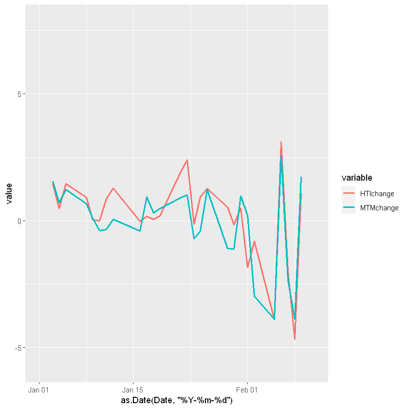

```r
data.frame(Date=Stocks$Date,
         HTIchange= transmute(Stocks, HTIchange=((HTI-lag(HTI))/lag(HTI))*100),
        MTMchange = transmute(Stocks, MTMchange=((MTM-lag(MTM))/lag(MTM))*100)) %>%
reshape2::melt(id.vars="Date") %>%
ggplot(aes(x=as.Date(Date,"%Y-%m-%d"), y=value, group=variable, color=variable)) + geom_line(size=1) +
 scale_x_date(limit=c(as.Date("2018-01-01"),as.Date("2018-02-11")))
```

# The graph above shoes the HTI change and MTM change from January to February.

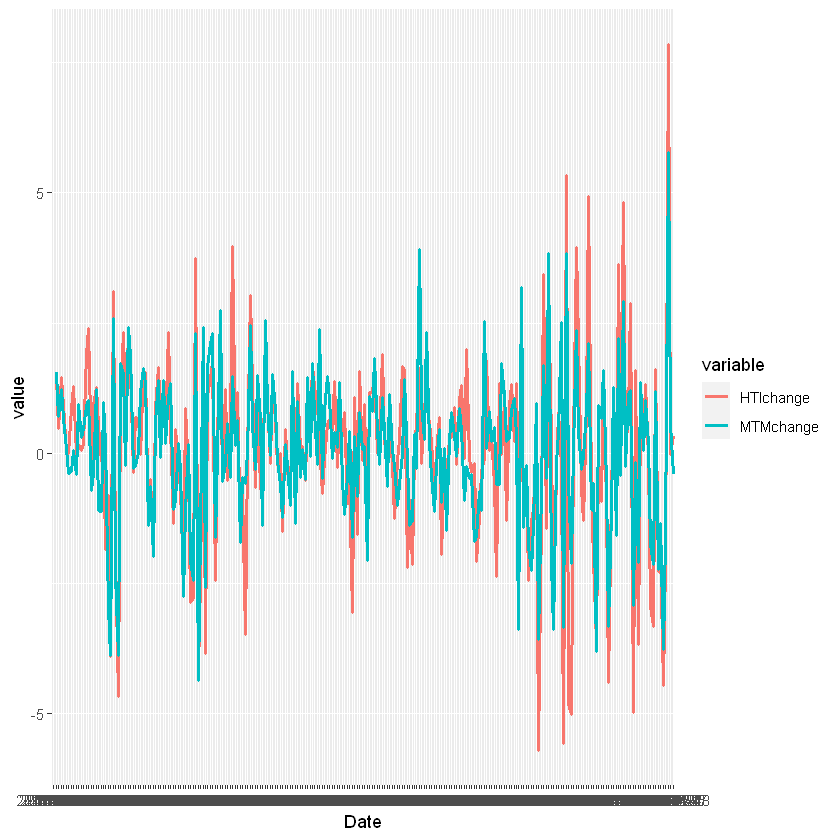

```r
data.frame(Date=Stocks$Date,
         HTIchange= transmute(Stocks, HTIchange=((HTI-lag(HTI))/lag(HTI))*100),
        MTMchange = transmute(Stocks, MTMchange=((MTM-lag(MTM))/lag(MTM))*100)) %>%
reshape2::melt(id.vars="Date") %>%
ggplot(aes(x=Date, y=value, group=variable, color=variable)) + geom_line(size=1)
```

# The above graph shows the same data but from January to December.

```r
jpy_close = JPY[, c('Date', 'Close')]
#jpy_close$Date = as.Date(jpy_close$Date)
nrow(jpy_close)
jpy_close = rename(jpy_close, 'JPY_Close' = 'Close')
head(jpy_close)
```

261

A data.frame: 6 × 2

|  | Date <chr> | JPY_Close <dbl> |
| --- | --- | --- |
| 1 | 2018-01-01 | 112.666000 |
| 2 | 2018-01-02 | 112.769997 |
| 3 | 2018-01-03 | 112.244003 |
| 4 | 2018-01-04 | 112.607002 |
| 5 | 2018-01-05 | 112.782997 |
| 6 | 2018-01-08 | 113.153999 |

```r
newStocks = merge(Stocks, jpy_close, by = 'Date')
head(newStocks)
```

A data.frame: 6 × 25

|  | Date <chr> | Apple_Close <dbl> | Apple_AdjClose <dbl> | Amazon_Close <dbl> | Amazon_AdjClose <dbl> | FB_Close <dbl> | FB_AdjClose <dbl> | Google_Close <dbl> | Google_AdjClose <dbl> | IBM_Close <dbl> | ... | ORCL_Close <dbl> | ORCL_AdjClose <dbl> | SAP_Close <dbl> | SAP_AdjClose <dbl> | TSLA_Close <dbl> | TSLA_AdjClose <dbl> | Remaining <dbl> | MTM <dbl> | HTI <dbl> | JPY_Close <dbl> |
| --- | --- | --- | --- | --- | --- | --- | --- | --- | --- | --- | --- | --- | --- | --- | --- | --- | --- | --- | --- | --- | --- |
| 1 | 2018-01-02 | 43.064999 | 41.380238 | 1189.01001 | 1189.01001 | 181.419998 | 181.419998 | 1065.00000 | 1065.00000 | 154.250000 | ... | 46.630001 | 44.173431 | 112.389999 | 107.653435 | 64.106003 | 64.106003 | 1294.787516 | 5000000.00 | 314.289101 | 112.769997 |
| 2 | 2018-01-03 | 43.057499 | 41.373032 | 1204.19995 | 1204.19995 | 184.669998 | 184.669998 | 1082.47998 | 1082.47998 | 158.490005 | ... | 47.709999 | 45.196526 | 113.309998 | 108.534660 | 63.450001 | 63.450001 | 1294.787516 | 5077927.50 | 318.876743 | 112.244003 |
| 3 | 2018-01-04 | 43.257500 | 41.565216 | 1209.58997 | 1209.58997 | 184.330002 | 184.330002 | 1086.40002 | 1086.40002 | 161.699997 | ... | 48.180000 | 45.641769 | 115.050003 | 110.201332 | 62.924000 | 62.924000 | 1294.787516 | 5113912.49 | 320.417150 | 112.607002 |
| 4 | 2018-01-05 | 43.750000 | 42.038452 | 1229.14001 | 1229.14001 | 186.850006 | 186.850006 | 1102.22998 | 1102.22998 | 162.490005 | ... | 48.470001 | 45.916508 | 116.330002 | 111.427383 | 63.316002 | 63.316002 | 1294.787516 | 5176778.40 | 325.075602 | 112.782997 |
| 5 | 2018-01-08 | 43.587502 | 41.882305 | 1246.87000 | 1246.87000 | 188.279999 | 188.279999 | 1106.93994 | 1106.93994 | 163.470001 | ... | 48.980000 | 46.399624 | 114.800003 | 109.961861 | 67.281998 | 67.281998 | 1294.787516 | 5211388.74 | 328.053944 | 113.153999 |
| 6 | 2018-01-09 | 43.582500 | 41.877506 | 1252.69995 | 1252.69995 | 187.869995 | 187.869995 | 1106.26001 | 1106.26001 | 163.830002 | ... | 49.060001 | 46.656403 | 114.160004 | 109.348839 | 66.737999 | 66.737999 | 249.110183 | 5216324.31 | 328.173046 | 113.140999 |